# Sunk Cost Fallacy and Seller Behavior in the Housing Market

Dimuthu Ratnadiwakara and Vijay Yerramilli

October 20, 2017

# 1 Descriptive Statistics

This table provides descriptive statistics of the main sample-a sample of recently sold houses in California.

```
##
## ==================================================================================================
## Statistic                      Mean       St. Dev.     Pctl(25)      Median      Pctl(75)     N
## --------------------------------------------------------------------------------------------------
## purchased_amount           445,804.2000 329,060.8000   225,000      357,000      560,500    76,126
## adj_purch_price            602,984.5000 429,111.0000 319,730.4000 488,280.4000 743,041.0000 76,126
## listing_amount             651,158.2000 474,858.5000   349,900      519,000      775,000    76,126
## sales_price                631,467.5000 448,564.1000   345,000      510,000      755,000    76,126
## list_price_adj_purch_price    1.1102       0.2471       0.9647       1.0528       1.1785    76,126
## list_price_trans_price        1.0293       0.1117       0.9970       1.0159       1.0524    76,126
## days_on_markt                87.9298      68.8572         46           66          106      76,126
## property_tax_paid          26,321.4000  19,032.2900     13,700       22,010       33,635    55,145
## prop_tax_adj_purch_price      0.0457       0.0157       0.0381       0.0459       0.0540    55,145
## prop8_affected                0.3404       0.4739         0            0            1       76,126
## purchased_hpi              428,045.9000 293,898.0000   231,900      359,000      540,500    76,126
## list_hpi_purch_hpi            1.4531       0.5222       1.1239       1.3196       1.6037    76,126
## ownership_years               8.5776       5.0768         4            8            13      76,126
## years_since_remodel          40.4016      24.4434         18           38           59      8,593
## beds                          3.4054       0.8734         3            3            4       76,126
## baths                         2.4641       0.9465       2.0000       2.0000       3.0000    75,770
## sqft                        1,956.9010    842.5455      1,365        1,759        2,363     76,126
## avg_school_rating             6.6217       2.1005       5.0000       6.6667       8.3333    76,054
## avg_school_distance           1.4439       1.2925       0.8000       1.1333       1.6667    76,065
## age                          39.6857      26.4979         18           36           58      73,370
## Lot                         5,150.6260   3,309.0480     2,962        5,998        7,405     73,670
## --------------------------------------------------------------------------------------------------
##
```

# 2 Correlation matrix

```
##                        tax_rate log_prop_tax_paid log_list_price
## tax_rate             1.00000000        0.22701234     -0.1561616
## log_prop_tax_paid    0.22701234        1.00000000      0.8706441
## log_list_price      -0.15616156        0.87064409      1.0000000
## log_purchase_price   0.08317028        0.89050493      0.8342134
## log_adj_purch_price -0.23251513        0.88074808      0.9575036
## log_HPI_purchase     0.16849796        0.74202123      0.7073080
## ownership_years     -0.36004840       -0.03801213      0.1056612
##                     log_purchase_price log_adj_purch_price
## tax_rate                    0.08317028          -0.2325151
## log_prop_tax_paid           0.89050493           0.8807481
## log_list_price              0.83421342           0.9575036
## log_purchase_price          1.00000000           0.8569842
## log_adj_purch_price         0.85698422           1.0000000
## log_HPI_purchase            0.85287695           0.6680140
## ownership_years            -0.14868454           0.1479554
##                     log_HPI_purchase ownership_years
## tax_rate                   0.1684980     -0.36004840
## log_prop_tax_paid          0.7420212     -0.03801213
## log_list_price             0.7073080      0.10566119
## log_purchase_price         0.8528769     -0.14868454
## log_adj_purch_price        0.6680140      0.14795541
## log_HPI_purchase           1.0000000     -0.23825386
## ownership_years           -0.2382539      1.00000000
```

## 2.1 Property Taxes and House Prices in California

This figure shows the relationship between the property tax rate in 2015 and the median house price in the zip code at the time of purchase in California. Tax rate is defined as the property taxes paid in 2015 as a percentage of estimated home value in 2015. Home value is estimated by inflating the purchased price by house price appreciation rate from purchased year to year 2015.

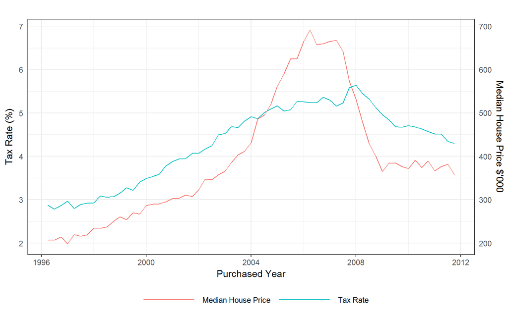

Following figure shows the histogram of within zip code tax rate variation. Tax rate for each house is calculated by dividing the property tax amount in the year prior to listing by the estimated house value in the year of listing. X-axis is the difference between the tax rate of each house and the mean tax rate of each zip code.

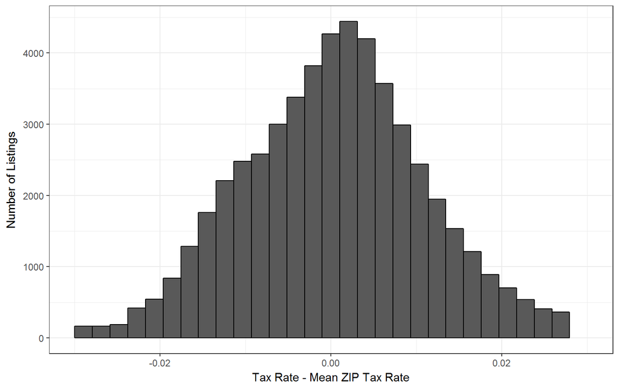

# 3 Main Result

```
##
## =================================================================================================
##                                 Y: log(listing amount) ; iv: log(purchased hpi)+ownership years
##                               -------------------------------------------------------------------
##                                    OLS       First Stage       IV        Prop.8 = 0   Prop.8 = 1
##                                    (1)           (2)           (3)          (4)          (5)
## -------------------------------------------------------------------------------------------------
## log(property_tax_paid)          0.084***
##                                  (0.005)
## log(purchased_hpi)                            0.411***
##                                                (0.011)
## ownership_years                               -0.011***
##                                                (0.002)
## prop8_affected                  -0.030***     0.052***      -0.034***
##                                  (0.002)       (0.005)       (0.003)
## log(adj_purch_price)            0.431***      0.727***      0.398***      0.416***     0.335***
##                                  (0.009)       (0.008)       (0.012)      (0.014)      (0.019)
## sqft                            0.0001***     0.0001***     0.0001***    0.0001***    0.0001***
##                                 (0.00000)     (0.00000)     (0.00000)    (0.00001)    (0.00001)
## age                             0.001***      -0.001***     0.001***      0.001***     0.001**
##                                 (0.0002)      (0.0003)      (0.0002)      (0.0001)     (0.0004)
## beds                            0.007***      0.014***      0.006***      0.007***      0.003
##                                  (0.002)       (0.002)       (0.002)      (0.002)      (0.002)
## baths                           0.009***       0.007**      0.008***      0.017***      0.004
##                                  (0.003)       (0.003)       (0.003)      (0.003)      (0.003)
## log(Lot)                        -0.007***     0.003***      -0.007***    -0.007***    -0.007***
##                                  (0.001)       (0.001)       (0.001)      (0.001)      (0.001)
## walk_score                     -0.0004***    -0.0004***    -0.0004***    -0.0005***    -0.0002
##                                 (0.0001)      (0.0001)      (0.0001)      (0.0001)     (0.0001)
## avg_school_rating               0.011***      0.012***      0.010***      0.011***     0.007***
##                                  (0.002)       (0.002)       (0.002)      (0.002)      (0.002)
## avg_school_distance             0.006***        0.002       0.006***      0.008***     0.003**
##                                  (0.001)       (0.002)       (0.001)      (0.002)      (0.001)
## `log(property_tax_paid)(fit)`                               0.130***      0.063***     0.307***
##                                                              (0.012)      (0.014)      (0.026)
## -------------------------------------------------------------------------------------------------
## Cond. F. Stat                                                133.86        124.62       38.51
## Observations                     47,472        47,472        47,472        24,768       22,704
## Adjusted R2                       0.955         0.887         0.955        0.954        0.955
## =================================================================================================
## Note:                                                                 *p<0.1; **p<0.05; ***p<0.01
##                                                                 Fixed Effects: zip x listed month
##                                                   Standard Errors clustered by zip x listed month
```

# 4 Main Result: Entire ownership

```
##
## =================================================================================================
##                                 Y: log(listing amount) ; iv: log(purchased hpi)+ownership years
##                               -------------------------------------------------------------------
##                                    OLS       First Stage       IV        Prop.8 = 0   Prop.8 = 1
##                                    (1)           (2)           (3)          (4)          (5)
## -------------------------------------------------------------------------------------------------
## log(property_tax_paid)          0.053***
##                                  (0.003)
## log(purchased_hpi)                            0.063***
##                                                (0.022)
## ownership_years                               0.202***
##                                                (0.003)
## prop8_affected                  -0.028***     0.122***      -0.025***
##                                  (0.003)       (0.010)       (0.003)
## log(adj_purch_price)            0.433***      0.808***      0.436***      0.416***     0.469***
##                                  (0.010)       (0.010)       (0.011)      (0.012)      (0.016)
## sqft                            0.0001***    0.00005***     0.0001***    0.0001***    0.0001***
##                                 (0.00000)     (0.00000)     (0.00000)    (0.00001)    (0.00001)
## age                             0.001***      -0.0002*      0.001***      0.001***     0.0005*
##                                 (0.0002)      (0.0001)      (0.0002)      (0.0001)     (0.0003)
## beds                             0.004**       0.007**       0.004**       0.003       0.006**
##                                  (0.002)       (0.003)       (0.002)      (0.002)      (0.003)
## baths                           0.010***       -0.002       0.010***      0.015***      0.004
##                                  (0.002)       (0.003)       (0.002)      (0.003)      (0.003)
## log(Lot)                        -0.007***      0.0003       -0.007***    -0.007***    -0.007***
##                                  (0.001)       (0.001)       (0.001)      (0.001)      (0.001)
## walk_score                     -0.0003***    -0.0003***    -0.0003***    -0.0003***   -0.0002**
##                                 (0.0001)      (0.0001)      (0.0001)      (0.0001)     (0.0001)
## avg_school_rating               0.010***      0.011***      0.010***      0.008***     0.012***
##                                  (0.002)       (0.002)       (0.002)      (0.002)      (0.002)
## avg_school_distance             0.004***        0.001       0.004***      0.005**      0.004**
##                                  (0.002)       (0.003)       (0.002)      (0.002)      (0.002)
## `log(property_tax_paid)(fit)`                               0.048***      0.051***     0.060***
##                                                              (0.003)      (0.005)      (0.011)
## -------------------------------------------------------------------------------------------------
## Cond. F. Stat                                                450.19         372         351.22
## Observations                     28,574        28,574        28,574        15,174       13,400
## Adjusted R2                       0.958         0.920         0.958        0.958        0.960
## =================================================================================================
## Note:                                                                 *p<0.1; **p<0.05; ***p<0.01
##                                                                 Fixed Effects: zip x listed month
##                                                   Standard Errors clustered by zip x listed month
```

# 5 Main Result (listprice/adj.purch price ~ tax rate)

```
##
## ==========================================================================================
##                        Y: degree of overpricing ; iv: log(purchased hpi)+ownership years
##                      ---------------------------------------------------------------------
##                           OLS       First Stage       IV        Prop.8 = 0    Prop.8 = 1
##                           (1)           (2)           (3)           (4)           (5)
## ------------------------------------------------------------------------------------------
## tax_rate               3.761***
##                         (0.243)
## log(purchased_hpi)                   0.018***
##                                      (0.0005)
## ownership_years                      -0.0001**
##                                      (0.0001)
## prop8_affected         -0.042***     0.002***      -0.041***
##                         (0.003)      (0.0002)       (0.004)
## log(adj_purch_price)   -0.575***     -0.015***     -0.581***     -0.651***     -0.433***
##                         (0.014)      (0.0004)       (0.015)       (0.017)       (0.022)
## sqft                   0.0002***    0.00000***     0.0002***     0.0002***     0.0001***
##                        (0.00001)     (0.00000)     (0.00001)     (0.00001)     (0.00001)
## age                    0.001***     -0.00004***    0.001***      0.001***       0.001**
##                        (0.0003)      (0.00002)     (0.0003)      (0.0001)      (0.0004)
## beds                   0.006***      0.001***      0.006***       0.007**        0.003
##                         (0.002)      (0.0001)       (0.002)       (0.003)       (0.002)
## baths                  0.011***       0.0002       0.011***      0.021***       0.005*
##                         (0.004)      (0.0001)       (0.004)       (0.003)       (0.003)
## log(Lot)               -0.009***     0.0001***     -0.009***     -0.009***     -0.009***
##                         (0.001)      (0.00003)      (0.001)       (0.001)       (0.001)
## walk_score            -0.0004***    -0.00003***   -0.0004***     -0.001***      -0.0002
##                        (0.0001)      (0.00001)     (0.0001)      (0.0001)      (0.0001)
## avg_school_rating      0.012***      0.001***      0.012***      0.013***      0.008***
##                         (0.002)      (0.0001)       (0.002)       (0.002)       (0.002)
## avg_school_distance    0.008***       0.0001       0.008***      0.011***       0.004**
##                         (0.002)      (0.0001)       (0.002)       (0.003)       (0.002)
## `tax_rate(fit)`                                    3.424***      2.167***      6.549***
##                                                     (0.369)       (0.443)       (0.626)
## ------------------------------------------------------------------------------------------
## Cond. F. Stat                                       152.11        167.76         50.97
## Observations            46,928        46,928        46,928        24,366        22,562
## Adjusted R2              0.495         0.607         0.494         0.534         0.449
## ==========================================================================================
## Note:                                                          *p<0.1; **p<0.05; ***p<0.01
##                                                          Fixed Effects: zip x listed month
##                                            Standard Errors clustered by zip x listed month
```

# 6 Main Result - Split by HPI

```
##
## =========================================================================================
##                       Y: degree of overpricing ; iv: log(purchased hpi)+ownership years
##                      --------------------------------------------------------------------
##                          Loss-OLS          Loss-IV        No Loss-OLS       No Loss-IV
##                             (1)              (2)              (3)              (4)
## -----------------------------------------------------------------------------------------
## tax_rate                 4.983***                           3.617***
##                           (0.391)                           (0.264)
## log(adj_purch_price)     -0.397***          -0.018         -0.591***        -0.607***
##                           (0.029)          (0.123)          (0.014)          (0.014)
## prop8_affected           -0.104***        -0.176***        -0.038***        -0.034***
##                           (0.018)          (0.031)          (0.003)          (0.003)
## sqft                     0.0001***         0.00001         0.0002***        0.0002***
##                          (0.00001)        (0.00004)        (0.00001)        (0.00001)
## age                      0.002***          0.003***         0.001***         0.001***
##                          (0.0002)          (0.001)          (0.0004)         (0.0003)
## baths                      0.003            0.003           0.016***         0.016***
##                           (0.003)          (0.003)          (0.003)          (0.003)
## beds                      -0.002           -0.011*          0.006***         0.006***
##                           (0.004)          (0.006)          (0.002)          (0.002)
## Lot                     -0.00000***      -0.00001***      -0.00000***      -0.00000***
##                          (0.00000)        (0.00000)        (0.00000)        (0.00000)
## walk_score               -0.001***         -0.0003         -0.0005***       -0.001***
##                          (0.0002)          (0.0003)         (0.0001)         (0.0001)
## avg_school_rating        0.010***           -0.006          0.012***         0.013***
##                           (0.004)          (0.007)          (0.002)          (0.002)
## avg_school_distance       0.006**           0.004           0.008***         0.008***
##                           (0.003)          (0.003)          (0.002)          (0.002)
## `tax_rate(fit)`                           21.156***                          2.510***
##                                            (4.916)                           (0.355)
## -----------------------------------------------------------------------------------------
##
## Observations               7,230            7,230            39,698           39,698
## Adjusted R2                0.431            -0.053           0.505            0.503
## =========================================================================================
## Note:                                                         *p<0.1; **p<0.05; ***p<0.01
##                                                               Fixed Effects: listed month
##                                           Standard Errors clustered by zip x listed month
```

# 7 Main Result - Split by Home Value

```
##
## =========================================================================================
##                       Y: degree of overpricing ; iv: log(purchased hpi)+ownership years
##                      --------------------------------------------------------------------
##                        Low Value OLS     Low Value IV    High Value OLS   High Value IV
##                             (1)              (2)              (3)              (4)
## -----------------------------------------------------------------------------------------
## tax_rate                 2.954***                           3.850***
##                           (0.202)                           (0.392)
## log(adj_purch_price)     -0.688***        -0.709***        -0.711***        -0.670***
##                           (0.015)          (0.016)          (0.022)          (0.027)
## prop8_affected           -0.039***        -0.034***        -0.018***        -0.025***
##                           (0.003)          (0.003)          (0.006)          (0.007)
## sqft                     0.0002***        0.0002***        0.0001***        0.0001***
##                          (0.00001)        (0.00001)        (0.00001)        (0.00001)
## age                      0.001***          0.001***         0.002***         0.002***
##                          (0.0003)          (0.0002)         (0.0002)         (0.0002)
## baths                     0.005**          0.005**          0.019***         0.018***
##                           (0.002)          (0.003)          (0.004)          (0.004)
## beds                     0.021***          0.021***        -0.026***        -0.026***
##                           (0.002)          (0.002)          (0.003)          (0.003)
## Lot                     0.00000***        0.00000***      -0.00001***      -0.00001***
##                          (0.00000)        (0.00000)        (0.00000)        (0.00000)
## walk_score              -0.0005***        -0.001***        -0.001***        -0.0005***
##                          (0.0001)          (0.0001)         (0.0002)         (0.0002)
## avg_school_rating        0.014***          0.014***          0.004            0.004
##                           (0.002)          (0.002)          (0.003)          (0.003)
## avg_school_distance        0.001            0.001           0.012***         0.011***
##                           (0.002)          (0.002)          (0.004)          (0.004)
## `tax_rate(fit)`                            1.626***                          5.702***
##                                            (0.337)                           (0.740)
## -----------------------------------------------------------------------------------------
## condf
## Observations              35,148            35,148           11,780           11,780
## Adjusted R2                0.596            0.594            0.570            0.566
## =========================================================================================
## Note:                                                         *p<0.1; **p<0.05; ***p<0.01
##                                                         Fixed Effects: zip x listed month
##                                           Standard Errors clustered by zip x listed month
```

# 8 Main Result - Split by LTV

```
##
## =========================================================================================
##                       Y: degree of overpricing ; iv: log(purchased hpi)+ownership years
##                      --------------------------------------------------------------------
##                        LTV < p70 OLS     LTV < p70 IV    LTV >= p70 OLS   LTV >= p70 IV
##                             (1)              (2)              (3)              (4)
## -----------------------------------------------------------------------------------------
## tax_rate                 3.486***                           3.815***
##                           (0.286)                           (0.338)
## log(adj_purch_price)     -0.597***        -0.608***        -0.570***        -0.537***
##                           (0.016)          (0.017)          (0.021)          (0.035)
## prop8_affected           -0.038***        -0.036***        -0.047***        -0.050***
##                           (0.004)          (0.004)          (0.007)          (0.008)
## sqft                     0.0002***        0.0002***        0.0002***        0.0002***
##                          (0.00001)        (0.00001)        (0.00001)        (0.00001)
## age                       0.001**          0.001**          0.002***         0.002***
##                          (0.0003)          (0.0003)         (0.0002)         (0.0002)
## baths                    0.011***          0.011***          0.003            0.003
##                           (0.003)          (0.003)          (0.003)          (0.003)
## beds                      -0.001            -0.001           0.004            0.003
##                           (0.002)          (0.002)          (0.004)          (0.004)
## Lot                     -0.00000***      -0.00000***       -0.00000**      -0.00000***
##                          (0.00000)        (0.00000)        (0.00000)        (0.00000)
## walk_score               -0.0003**        -0.0003**        -0.001***        -0.001***
##                          (0.0001)          (0.0001)         (0.0001)         (0.0001)
## avg_school_rating        0.011***          0.011***         0.016***         0.014***
##                           (0.002)          (0.002)          (0.003)          (0.003)
## avg_school_distance      0.010***          0.010***         0.007***         0.007***
##                           (0.003)          (0.003)          (0.003)          (0.003)
## `tax_rate(fit)`                            2.696***                          5.412***
##                                            (0.449)                           (1.383)
## -----------------------------------------------------------------------------------------
## condf
## Observations              23,636            23,636           10,005           10,005
## Adjusted R2                0.500            0.499            0.512            0.508
## =========================================================================================
## Note:                                                         *p<0.1; **p<0.05; ***p<0.01
##                                                         Fixed Effects: zip x listed month
##                                           Standard Errors clustered by zip x listed month
```

# 9 Main Result - Split by Market Activity

```
##
## ============================================================================================
##                         Y: degree of overpricing ; iv: log(purchased hpi)+ownership years
##                      -----------------------------------------------------------------------
##                      Low Liquidity OLS Low Liquidity IV High Liquidity OLS High Liquidity IV
##                             (1)              (2)               (3)                (4)
## --------------------------------------------------------------------------------------------
## tax_rate                 3.743***                            3.958***
##                           (0.302)                            (0.383)
## log(adj_purch_price)     -0.607***        -0.612***         -0.499***          -0.498***
##                           (0.017)          (0.017)           (0.022)            (0.025)
## prop8_affected           -0.037***        -0.036***         -0.053***          -0.053***
##                           (0.004)          (0.004)           (0.007)            (0.007)
## sqft                     0.0002***        0.0002***         0.0002***          0.0002***
##                          (0.00001)        (0.00001)         (0.00001)          (0.00001)
## age                       0.001**          0.001**           0.002***          0.002***
##                          (0.0003)          (0.0003)          (0.0002)          (0.0002)
## baths                    0.014***          0.014***           0.009*            0.009*
##                           (0.004)          (0.004)           (0.005)            (0.005)
## beds                     0.008***          0.008***           0.001              0.001
##                           (0.003)          (0.003)           (0.003)            (0.004)
## Lot                     -0.00000***      -0.00000***       -0.00000***        -0.00000***
##                          (0.00000)        (0.00000)         (0.00000)          (0.00000)
## walk_score               -0.001***        -0.001***         -0.0004***        -0.0004***
##                          (0.0001)          (0.0001)          (0.0002)          (0.0002)
## avg_school_rating        0.015***          0.015***          0.008**            0.008**
##                           (0.002)          (0.002)           (0.003)            (0.003)
## avg_school_distance      0.011***          0.011***          0.006***          0.006***
##                           (0.003)          (0.003)           (0.002)            (0.002)
## `tax_rate(fit)`                            3.394***                            4.056***
##                                            (0.451)                              (0.663)
## --------------------------------------------------------------------------------------------
## condf
## Observations              26,393            26,393            18,435            18,435
## Adjusted R2                0.511            0.511             0.453              0.453
## ============================================================================================
## Note:                                                            *p<0.1; **p<0.05; ***p<0.01
##                                                            Fixed Effects: zip x listed month
##                                              Standard Errors clustered by zip x listed month
```

# 10 Main Result - Split by Home Sales

```
##
## ================================================================================================
##                           Y: degree of overpricing ; iv: log(purchased hpi)+ownership years
##                      ---------------------------------------------------------------------------
##                      Low Home Sales OLS Low Home Sales IV High Home Sales OLS High Home Sales IV
##                             (1)                (2)                (3)                (4)
## ------------------------------------------------------------------------------------------------
## tax_rate                  5.118***                             3.084***
##                           (0.378)                               (0.307)
## log(adj_purch_price)     -0.532***          -0.539***          -0.592***          -0.587***
##                           (0.018)            (0.021)            (0.023)            (0.025)
## prop8_affected           -0.045***          -0.043***          -0.043***          -0.045***
##                           (0.005)            (0.005)            (0.005)            (0.005)
## sqft                     0.0002***          0.0002***          0.0002***          0.0002***
##                          (0.00001)          (0.00001)          (0.00001)          (0.00001)
## age                       0.001**            0.001**           0.002***            0.002***
##                           (0.0004)          (0.0004)           (0.0002)            (0.0002)
## baths                     0.012***          0.013***           0.018***            0.018***
##                           (0.004)            (0.004)            (0.003)            (0.003)
## beds                      0.008***          0.009***             0.003              0.003
##                           (0.003)            (0.003)            (0.003)            (0.003)
## Lot                       -0.00000          -0.00000          -0.00000***        -0.00000***
##                          (0.00000)          (0.00000)          (0.00000)          (0.00000)
## walk_score               -0.0003**          -0.0003**          -0.001***          -0.001***
##                           (0.0001)          (0.0001)           (0.0001)            (0.0001)
## avg_school_rating         0.018***          0.018***           0.010***            0.010***
##                           (0.003)            (0.003)            (0.003)            (0.003)
## avg_school_distance       0.008***          0.008***            0.006**            0.006**
##                           (0.003)            (0.003)            (0.003)            (0.003)
## `tax_rate(fit)`                             4.614***                               3.378***
##                                              (0.683)                               (0.510)
## ------------------------------------------------------------------------------------------------
## condf
## Observations               19,922            19,922             23,906              23,906
## Adjusted R2                0.469              0.468              0.524              0.524
## ================================================================================================
## Note:                                                                *p<0.1; **p<0.05; ***p<0.01
##                                                                Fixed Effects: zip x listed month
##                                                  Standard Errors clustered by zip x listed month
```

# 11 Selling Price and Time-on-market 3SLS Regs (Stata)

Data set is restricted to zipcodes with atleast 100 observations and Zip * Listed Year fixed effects are used due to insufficient computing power.

```
----------------------------------------------------------------------
                      (1)                                (2)
                Sales Price                        Days-on Market
----------------------------------------------------------------------
Model 1
Dep Var: log(Property Tax)
log(purchased hpi)  0.383***      (66.73)        0.383***      (66.74)
log(ownership days)-0.024***      (-7.23)      -0.0241***      (-7.20)
log(adj_purch_pr)   0.674***     (104.49)        0.674***     (104.49)
prop8_affected     0.0450***      (12.70)       0.0450***      (12.70)
sqft             0.000110***      (32.66)     0.000110***      (32.66)
age              -0.00278***     (-26.77)     -0.00278***     (-26.77)
beds              0.00964***       (4.43)      0.00964***       (4.43)
baths           -0.000669         (-0.38)    -0.000668         (-0.38)
Lot            0.00000184***       (4.38)   0.00000184***       (4.38)
walk_score      -0.000388***      (-4.62)    -0.000388***      (-4.62)
school_rating      0.0156***       (9.72)       0.0156***       (9.72)
school_distance   0.00189          (1.25)      0.00189          (1.25)
_cons              -3.783***     (-30.83)       -3.784***     (-30.84)
----------------------------------------------------------------------
Model 2
Dep Var: log(List Price)
log(Property Tax)   0.176***      (19.05)        0.177***      (19.13)
log(adj_purch_pr)   0.365***      (52.99)        0.364***      (52.85)
prop8_affected    -0.0341***     (-12.98)      -0.0343***     (-13.05)
sqft             0.000125***      (49.07)     0.000125***      (49.00)
age               0.00147***      (19.63)      0.00147***      (19.67)
beds              0.00211          (1.47)      0.00210          (1.46)
baths             0.00478***       (4.09)      0.00478***       (4.09)
Lot           -0.00000280***     (-10.09)  -0.00000281***     (-10.09)
walk_score      -0.000584***     (-10.51)    -0.000584***     (-10.50)
school_rating     0.00678***       (6.34)      0.00676***       (6.33)
school_distance   0.00503***       (5.05)      0.00502***       (5.05)
_cons               6.383***     (110.28)        6.381***     (110.24)
----------------------------------------------------------------------
Model 3
Dep Var: log(sales price)                    Dep Var: Days on market
log(List Price)     0.993***      (215.46)     -14.12***      (-3.93)
prop8_affected   0.000448          (0.50)       1.676*         (2.39)
sqft           -0.0000176***      (-4.44)      0.0198***       (5.68)
age             -0.000358***      (-8.39)       0.219***       (6.15)
beds              0.00302***       (3.96)      -0.573         (-1.06)
baths           -0.000472         (-0.75)       1.759***       (3.44)
Lot           0.000000632***       (3.96)   -0.000371**       (-2.66)
walk_score      0.0000741*         (2.19)     -0.0412         (-1.18)
school_distance  0.000609          (1.01)      -1.024*        (-2.48)
school_distance  -0.00147**       (-2.69)       1.974***       (4.80)
_cons               0.101          (0.60)       224.5          (4.88)
----------------------------------------------------------------------
N                   20051                        20051
----------------------------------------------------------------------
t statistics in parentheses
* p<0.05, ** p<0.01, *** p<0.001
```

# 12 Alternative identificatin strategy - Using Proposition 8

Proposition 8 allows a temporary reduction in assessed value when real property suffers a decline in value. Property 8 reductions can be initiated by either the homeowner or by the Assessor. In a declining real estate market, the Assessor may choose not to apply the annual inflation factors to a large number of properties.

If the assessor did not initiate a reduction, in order to be considered for Proposition 8 assessment, the homeowner should provide the assessor with information that supports his opinion that the market value for your property is less than the assessed value. According to BOE CA, the best supporting documentation is information on sales of comparable properties in your neighborhood. Owner should select two comparable sales that sold as close to the January 1 lien date as possible, but no later than March 31. The deadline for filling appeals for Proposition 8 reductions is Nov 30th or Sep 15th depending on the county.

If the assessor did not initiate a reduction, property tax bills of similar homes in the same neighborhood can differ due to several reasons.

- The evidence provided by the homeowners can be different and will result in differences in the revised assessment values
- Some homeowners may miss the deadline to submit the evidence in the current year so proposition 8 effect will apply one year after
- Some homeowners may not be aware of the procedure and this might result in filing for reductions sometime later

These differences in assessment value *reductions* are unlikely to be related to home characteristics or seller characterisitcs and therefore can be used as an instrument for property taxes paid.

## 12.1 Example 1: Difference due to missing deadline or not filing in the current year

Both the homes 395 Avenida Le Cuesta (Home A) and 1706 Kenwood Pl (Home B) are from the same zip code 92078. Both these homes were purchased in 2006 and were sold in 2016. Assessment value of Home A increased in year 2008 by 2% according to proposition 13, but the assessment value of Home B decreased by 16% in year 2008. However assessment value of Home A decreased by 23% in 2009 while assessment value in Home B decreased by only 10% in 2009. This means the homeowner in Home A did’t file for propersition 8 reduction in 2008 or missed the deadline resulting in a higher property tax payment in year 2008 compared to Home B. The graphs below shows this effect.

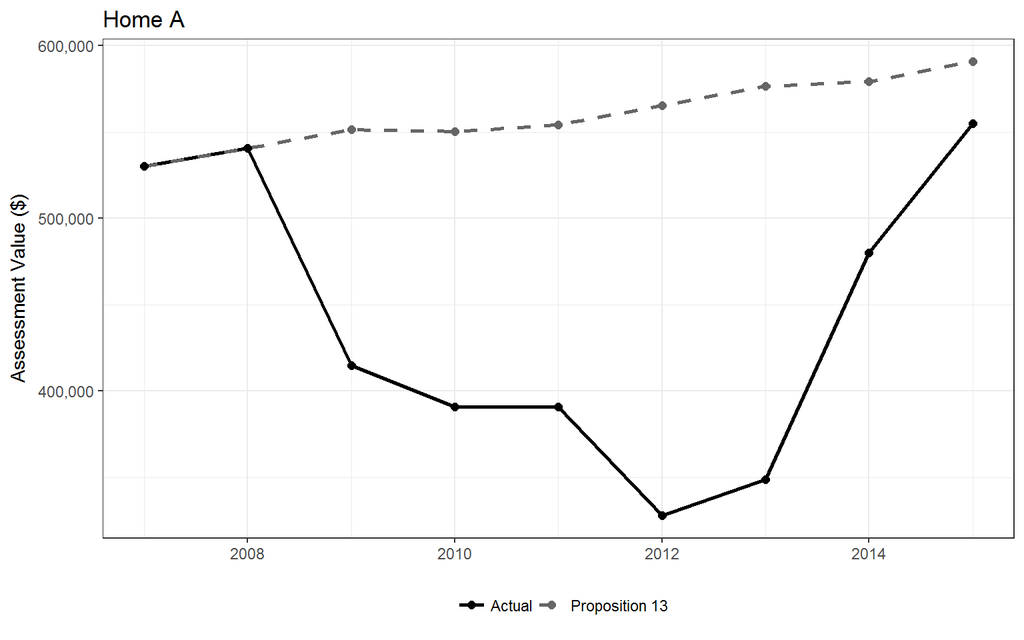

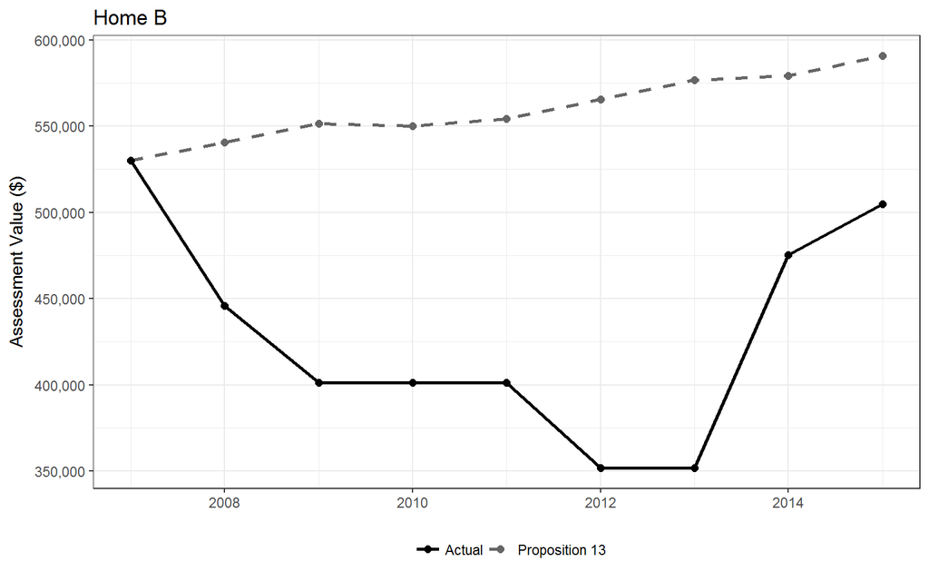

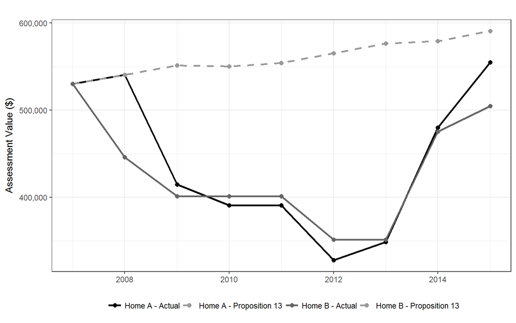

## 12.2 Example 2: Differences due to evidence

Both homes, 160 Providence Pl (A) and 313 Bradley Dr (B) are from the same zip code 95687. Both were purchased in 2006 for 482,000 and 483,500 respectively and were sold in 2016. Proposition 8 was applied to both these properties in 2008. Eventhough both properties were purchased around the same time for the same amount, there is some difference in the assessment value after proposition 8 took effect.

For Home A, difference between proposition 13 assessment and actual assessment is 3.92 times the purchased price and for home B the difference is 3.56 times the purchased price. This difference leads to differences in property taxes paid.

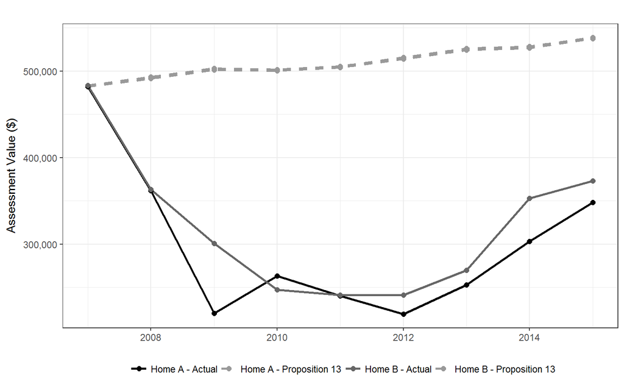

## 12.3 Regression

The following regression uses homes purchased in 2006 and sold in 2016.

The residual of this regression captures the deviations of of assessment values from the ‘true’ proposition 8 assessment values due to the reasons mentioned above. Therefore this residual can be used as an instrument for property taxes paid.

Results are similar for purchased years 2004, 05, 07 and 08.

```
##
## ===========================================================================
##                                Y: log(listing amount) ; iv: proptax resid
##                               ---------------------------------------------
##                                   OLS     First Stage     IV      Prop.Tax
##                                   (1)         (2)         (3)        (4)
## ---------------------------------------------------------------------------
## log(property_tax_paid)         0.101***
##                                 (0.035)
## proptax_resid                               0.106**
##                                             (0.045)
## log(adj_purch_price)           0.516***    0.548***    0.453***
##                                 (0.045)     (0.046)     (0.060)
## sqft                           0.0001***   0.0001***   0.0001***
##                                (0.00002)   (0.00002)   (0.00002)
## age                             0.0004      0.0004      0.0004
##                                (0.0003)    (0.0003)    (0.0003)
## beds                             0.004       0.005       0.004
##                                 (0.008)     (0.008)     (0.008)
## baths                           0.0003      0.0003      0.0002
##                                 (0.001)     (0.001)     (0.001)
## Lot                            -0.00000    -0.00000    -0.00000
##                                (0.00000)   (0.00000)   (0.00000)
## walk_score                     -0.0005*     -0.001*     -0.0005
##                                (0.0003)    (0.0003)    (0.0003)
## avg_school_rating                0.010       0.009       0.009
##                                 (0.006)     (0.006)     (0.006)
## avg_school_distance              0.005       0.006       0.005
##                                 (0.006)     (0.006)     (0.006)
## `log(property_tax_paid)(fit)`                          0.175***
##                                                         (0.062)
## log(assesment_2006)                                               0.324***
##                                                                    (0.012)
## ---------------------------------------------------------------------------
## Cond. F. Stat                                            0.24
## Observations                     1,996       1,996       1,996      1,996
## Adjusted R2                      0.959       0.959       0.958      0.751
## ===========================================================================
## Note:                                           *p<0.1; **p<0.05; ***p<0.01
##
```

# 13 Probability of Success

```
##
## ===================================================================
##                         Y: successful ; iv: log(prop tax paid)
##                     -----------------------------------------------
##                                    Low Liquidity OLS
## -------------------------------------------------------------------
## log(listing_amount)                    -0.011***
##                                         (0.004)
## sqft                                   -0.00002
##                                        (0.00001)
## age                                     0.0001
##                                        (0.0002)
## beds                                   0.030***
##                                         (0.011)
## baths                                   -0.007
##                                         (0.010)
## log(Lot)                                 0.003
##                                         (0.004)
## walk_score                              0.0003
##                                        (0.0004)
## avg_school_rating                       -0.004
##                                         (0.009)
## avg_school_distance                      0.004
##                                         (0.007)
## -------------------------------------------------------------------
## condf
## Observations                            10,039
## Adjusted R2                              0.040
## ===================================================================
## Note:                                   *p<0.1; **p<0.05; ***p<0.01
##                                   Fixed Effects: zip x listed month
##                     Standard Errors clustered by zip x listed month
```